# iDEP: Investigating Differentially Expressed Genes

## If this site has contributed to your work, please cite our article:

Ge, S.X., Son, E.W. & Yao, R. iDEP: an integrated web application for differential expression and pathway analysis of RNA-Seq data. BMC Bioinformatics 19, 534 (2018). https://doi.org/10.1186/s12859-018-2486-6

## Summary

Read Counts data were analyzed using iDEP v2.4.4. The data was first filtered to remove reads below 0.5 CPM in at least 1 sample. Then the data was transformed with EdgeR using a pseudocount of 4. Missing values were imputed using geneMedian.

After mapping, there are 32833 unique genes in 158 samples. Of the 24127 genes passed filter, 24127 were converted to Ensembl/STRING gene IDs in our database. The remaining 0 genes were kept in the data using original IDs.

Differential expression analysis was performed using DESeq2 with an FDR cutoff of 0.1 and a minimum fold-change threshold of 2. Standard Wald test was used and independent filtering was enabled.

## Selected Comparison: genotypeMYB3R135-genotypeWILDTYPE

Up-regulated genes: 184

Down-regulated genes: 27

## Top Up-regulated Genes

```r
if (!is.null(params$up_genes_table) && nrow(params$up_genes_table) > 0) {
  kbl(params$up_genes_table, escape = FALSE) %>%
    kable_classic(full_width = FALSE, html_font = "Cambria")
} else {
  print("No up-regulated genes found for this comparison.")
}
```

| Symbol | Ensembl ID | log2 FC | Adj. P-value | Description |
| --- | --- | --- | --- | --- |
| MRD1 | AT1G53480 | 15.847 | 1.05e-09 | Mto 1 responding down 1 |
| AT1G62515 | AT1G62515 | 14.674 | 1.57e-03 | Uncharacterized protein |
| AT1G05767 | AT1G05767 | 9.981 | 1.10e-03 | S-adenosyl-L-methionine-dependent methyltransferases superfamily protein |
| AT1G23050 | AT1G23050 | 6.608 | 5.08e-02 | Hydroxyproline-rich glycoprotein family protein |
| BSU1 | AT1G03445 | 6.482 | 6.99e-72 | Serine/threonine protein phosphatase family protein |
| PCC1 | AT3G22231 | 6.092 | 2.57e-04 | Pathogen and circadian controlled 1 |
| PDF1.2 | AT5G44420 | 5.203 | 6.37e-02 | Plant defensin 1.2 |
| AT5G62240 | AT5G62240 | 5.087 | 1.35e-18 | Cell cycle regulated microtubule associated protein |
| AT5G06695 | AT5G06695 | 5.020 | 4.93e-02 | NcRNA |
| LURP1 | AT2G14560 | 4.819 | 4.74e-03 | LURP-one-like protein (DUF567) |
| AT1G04183 | AT1G04183 | 4.742 | 6.39e-02 | NcRNA |
| AT1G10980 | AT1G10980 | 4.301 | 7.14e-06 | Lung seven transmembrane receptor family protein |
| PDF1.3 | AT2G26010 | 4.190 | 1.02e-02 | Plant defensin 1.3 |
| AT3G05950 | AT3G05950 | 3.836 | 5.76e-02 | RmlC-like cupins superfamily protein |
| AT3G01015 | AT3G01015 | 3.782 | 2.20e-08 | TPX2 (targeting protein for Xklp2) protein family |
| IQD16 | AT4G10640 | 3.713 | 6.50e-02 | IQ-domain 16 |
| PAP26 | AT5G34850 | 3.706 | 2.09e-38 | Purple acid phosphatase 26 |
| BZO1 | AT1G65880 | 3.705 | 1.46e-02 | Benzoyloxyglucosinolate 1 |
| SNAP29 | AT5G07880 | 3.509 | 1.55e-04 | Synaptosomal-associated protein SNAP25-like 29 |
| AT1G51770 | AT1G51770 | 3.497 | 9.89e-02 | Core-2/I-branching beta-1,6-N-acetylglucosaminyltransferase family protein |
| AT1G70220 | AT1G70220 | 3.212 | 3.04e-03 | RNA-processing, Lsm domain-containing protein |
| AT5G42330 | AT5G42330 | 3.119 | 9.99e-15 | Uncharacterized protein |
| AT2G47050 | AT2G47050 | 3.091 | 4.15e-03 | Plant invertase/pectin methylesterase inhibitor superfamily protein |
| HAP2 | AT4G11720 | 3.069 | 9.06e-05 | Hapless 2 |
| ARI3 | AT3G27710 | 3.022 | 7.75e-02 | RING/U-box superfamily protein |
| AT1G48740 | AT1G48740 | 2.768 | 3.40e-15 | 2-oxoglutarate (2OG) and Fe(II)-dependent oxygenase superfamily protein |
| AT5G28520 | AT5G28520 | 2.722 | 4.88e-02 | Mannose-binding lectin superfamily protein |
| AT3G28155 | AT3G28155 | 2.693 | 4.12e-02 | Uncharacterized protein |
| AT3G02620 | AT3G02620 | 2.679 | 7.53e-08 | Plant stearoyl-acyl-carrier-protein desaturase family protein |
| CDKD1;1 | AT1G73690 | 2.640 | 2.32e-24 | Cyclin-dependent kinase D1 |
| EDE1 | AT2G44190 | 2.582 | 1.81e-07 | ENDOSPERM DEFECTIVE protein (DUF566) |
| TCP1 | AT1G67260 | 2.567 | 4.51e-02 | TCP family transcription factor |
| DL1B | AT3G61760 | 2.534 | 5.39e-36 | DYNAMIN-like 1B |
| RPS2 AT4G26090 | AT4G26090 | 2.484 | 3.88e-02 | NB-ARC domain-containing disease resistance protein |
| RCK | AT3G27730 | 2.445 | 1.76e-05 | DNA helicase ROCK-N-ROLLERS |
| AT5G56700 | AT5G56700 | 2.438 | 1.96e-02 | FBD / Leucine Rich Repeat domains containing protein |
| AT5G42700 | AT5G42700 | 2.408 | 3.40e-06 | AP2/B3-like transcriptional factor family protein |
| AT2G16270 | AT2G16270 | 2.398 | 3.37e-06 | Uncharacterized protein |
| AT3G26050 | AT3G26050 | 2.391 | 3.83e-05 | TPX2 (targeting protein for Xklp2) protein family |
| AT4G28230 | AT4G28230 | 2.370 | 3.68e-05 | Uncharacterized protein |
| AT5G66840 | AT5G66840 | 2.365 | 2.00e-03 | SAP domain-containing protein |
| AT4G14490 | AT4G14490 | 2.337 | 1.63e-11 | SMAD/FHA domain-containing protein |
| RUG1 | AT5G08710 | 2.310 | 2.79e-24 | Regulator of chromosome condensation (RCC1) family protein |
| AT5G11870 | AT5G11870 | 2.300 | 2.98e-03 | Alkaline phytoceramidase (aPHC) |
| AT5G43660 | AT5G43660 | 2.283 | 3.20e-07 | 2-oxoglutarate (2OG) and Fe(II)-dependent oxygenase superfamily protein |
| AT4G09060 | AT4G09060 | 2.243 | 1.34e-03 | Uncharacterized protein |
| ZYP1b | AT1G22275 | 2.243 | 4.15e-09 | Myosin heavy chain-related protein |
| AT2G23530 | AT2G23530 | 2.242 | 5.41e-09 | Zinc-finger domain of monoamine-oxidase A repressor R1 |
| AT1G79103 | AT1G79103 | 2.226 | 4.99e-02 | Uncharacterized protein |
| AT3G57160 | AT3G57160 | 2.221 | 1.97e-10 | Cysteine-rich TM module stress tolerance protein |

## Top Down-regulated Genes

```r
if (!is.null(params$down_genes_table) && nrow(params$down_genes_table) > 0) {
  kbl(params$down_genes_table, escape = FALSE) %>%
    kable_classic(full_width = FALSE, html_font = "Cambria")
} else {
  print("No down-regulated genes found for this comparison.")
}
```

| Symbol | Ensembl ID | log2 FC | Adj. P-value | Description |
| --- | --- | --- | --- | --- |
| AT5G01645 | AT5G01645 | -25.123 | 9.26e-18 | NcRNA |
| AT4G08015 | AT4G08015 | -19.005 | 2.42e-03 | NcRNA |
| AT1G25055 | AT1G25055 | -16.490 | 1.38e-05 | F-box family protein |
| AT1G08723 | AT1G08723 | -16.297 | 5.32e-13 | NcRNA |
| SESA5 | AT5G54740 | -14.911 | 2.96e-06 | Seed storage albumin 5 |
| AT5G43490 | AT5G43490 | -11.926 | 3.92e-02 | Myb-like protein X |
| GMD1 | AT5G66280 | -8.527 | 5.81e-03 | GDP-D-mannose 4,6-dehydratase 1 |
| AT1G64795 | AT1G64795 | -7.638 | 1.51e-08 | Uncharacterized protein |
| ath-MIR5642a | AT3G06345 | -5.637 | 3.53e-03 | Ath-MIR5642a |
| AT2G01010 | AT2G01010 | -5.426 | 8.85e-02 | 18S ribosomal RNA |
| AT1G11090 | AT1G11090 | -5.150 | 3.29e-03 | Alpha/beta-Hydrolases superfamily protein |
| AT3G23060 | AT3G23060 | -3.887 | 6.47e-02 | RING/U-box superfamily protein |
| AT1G24851 | AT1G24851 | -2.952 | 3.80e-02 | Uncharacterized protein |
| MYB3R-5 | AT5G02320 | -2.922 | 1.51e-15 | Myb domain protein 3r-5 |
| AT1G24881 | AT1G24881 | -2.909 | 5.87e-02 | F-box family protein |
| CYP712A1 | AT2G42250 | -2.180 | 4.51e-03 | Cytochrome P450, family 712, subfamily A, polypeptide 1 |
| MYB3R-3 | AT3G09370 | -2.077 | 6.77e-22 | Myb domain protein 3r-3 |
| AT1G16489 | AT1G16489 | -1.584 | 2.25e-06 | NcRNA |
| AT2G19340 | AT2G19340 | -1.574 | 2.45e-03 | Oligosaccharyltransferase complex/magnesium transporter family protein |
| MEE23 | AT2G34790 | -1.367 | 1.59e-04 | FAD-binding Berberine family protein |
| CYP91A2 | AT4G37430 | -1.278 | 4.19e-02 | Cytochrome P450, family 91, subfamily A, polypeptide 2 |
| AT4G15890 | AT4G15890 | -1.224 | 2.24e-07 | Binding protein |
| AT2G39280 | AT2G39280 | -1.208 | 1.83e-07 | Ypt/Rab-GAP domain of gyp1p superfamily protein |
| AT1G04090 | AT1G04090 | -1.160 | 8.20e-03 | Vacuolar sorting-associated protein (DUF946) |
| AT3G16650 | AT3G16650 | -1.122 | 1.22e-05 | Transducin/WD40 repeat-like superfamily protein |
| PC-MYB1 | AT4G32730 | -1.018 | 4.03e-09 | Homeodomain-like protein |
| AT1G13990 | AT1G13990 | -1.009 | 9.11e-02 | Plant/protein |

## DEG Heatmap

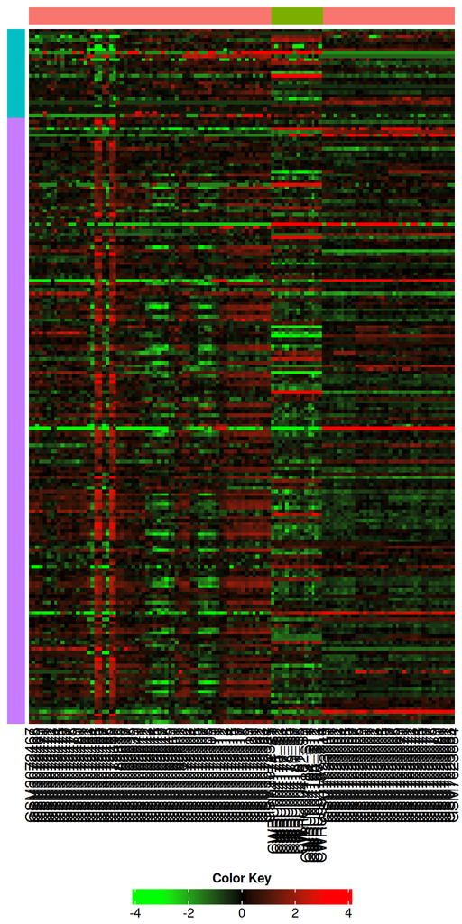

```r
if (!is.null(params$heat_data) && !is.null(params$heat_bar)) {
  heat_colors <- unlist(strsplit(params$heatmap_color_select, "-"))

  deg_heatmap(
    df = params$heat_data,
    bar = params$heat_bar,
    heatmap_color_select = heat_colors,
    cluster_rows = FALSE
  )
}
```

## Volcano Plot

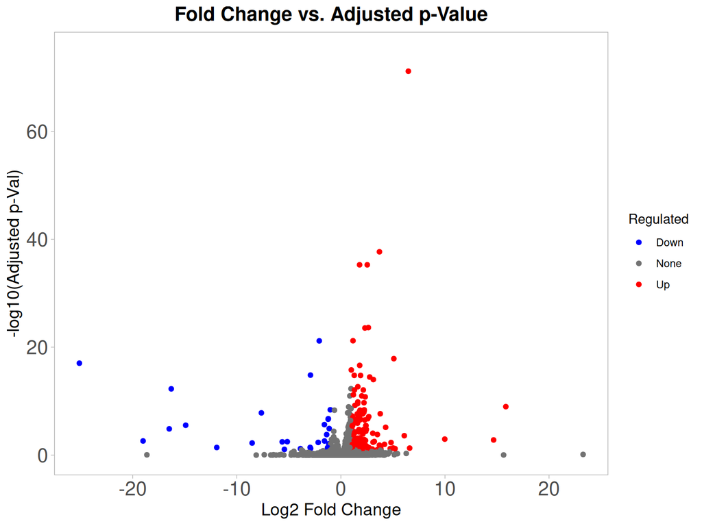

```r
if (!is.null(params$vol_data) && !is.null(params$vol_data$data)) {
  p <- plot_volcano(
    data = params$vol_data$data,
    plot_colors = params$plot_colors,
    anotate_genes = params$gene_labels_volcano
  )
  p <- refine_ggplot2(
    p = p,
    gridline = params$plot_grid_lines,
    ggplot2_theme = params$ggplot2_theme
  )
  print(p)
}
```